# DSA5209 HW3 Prob 3

### Problem 3

Estimate $I = \int_{\mathbb{R}^2} -\log|x-y|\,\psi(x)\psi(y)\,dx\,dy$ where $\psi = \mathcal{N}(0,\sigma^2)$, $\sigma=1/4$. True value $I\approx 1.6749$.

```python
import numpy as np
import matplotlib.pyplot as plt
import time
from scipy.stats import norm

np.random.seed(42)
sigma   = 1/4
sigma_u = np.sqrt(2) * sigma   # std of u = x-y
TRUE_I  = 1.6749
print(f'sigma={sigma}, sigma_u={sigma_u:.4f}, True I={TRUE_I}')
```

```
sigma=0.25, sigma_u=0.3536, True I=1.6749
```

## 1. Basic Monte Carlo

Since $\psi(x)\psi(y)$ is the joint density, draw $x,y\sim\mathcal{N}(0,\sigma^2)$ and average $-\log|x-y|$:

$$I_N = \frac{1}{N}\sum_{i=1}^N -\log|x_i-y_i|$$

**Difficulty:** $-\log|u|\to\infty$ as $u\to 0$. Many samples fall near $x\approx y$, inflating variance.

```python
def monte_carlo(N):
    t0 = time.perf_counter()
    x   = np.random.normal(0, sigma, N)
    y   = np.random.normal(0, sigma, N)
    diff = np.abs(x - y)
    vals = np.where(diff > 1e-300, -np.log(diff), 0.0)
    est  = np.mean(vals)
    ms   = (time.perf_counter() - t0) * 1000
    return est, ms

est, t = monte_carlo(100_000)
print(f'MC (N=100k): {est:.4f}  error={abs(est-TRUE_I):.4f}  time={t:.2f}ms')
```

```
MC (N=100k): 1.6784  error=0.0035  time=6.25ms
```

## 2. Importance Sampling

### Reformulation

Let $u=x-y$. Since $x,y\sim\mathcal{N}(0,\sigma^2)$ independently, $u\sim g=\mathcal{N}(0,2\sigma^2)$, so:

$$I = \mathbb{E}_g[-\log|u|]$$

### Why naive MC has high variance

The function $h(u)=-\log|u|$ spikes sharply near $u=0$. The Gaussian $g$ has non-negligible mass near 0, so many samples produce very large $h(u_i)$, blowing up the variance.

### IS strategy: mixture proposal

We want a proposal $q$ that **oversamples near $u=0$** (where $h$ is large) relative to $g$. We use a **mixture**:

$$q(u) = (1-\varepsilon)\,g(u) + \varepsilon\,\text{Uniform}(-\delta,\delta)$$

with $\varepsilon=0.3$, $\delta=0.05$. The uniform component injects extra samples into the dangerous region near 0. Importance weights correct for the tilting:

$$w_i = \frac{g(u_i)}{q(u_i)}, \qquad I_N^{IS} = \frac{\sum_i w_i h(u_i)}{\sum_i w_i}$$

```python
eps   = 0.3
delta = 0.05

def sample_q(N):
    """Draw N samples from the mixture proposal q."""
    n_g = int(N * (1 - eps))
    n_u = N - n_g
    return np.concatenate([
        np.random.normal(0, sigma_u, n_g),
        np.random.uniform(-delta, delta, n_u)
    ])

def log_q_pdf(u):
    """Log-density of the mixture proposal."""
    log_g    = norm.logpdf(u, scale=sigma_u)
    log_unif = np.where(np.abs(u) <= delta,
                        np.log(1/(2*delta)), -np.inf)
    return np.logaddexp(np.log(1-eps) + log_g,
                        np.log(eps)   + log_unif)

def importance_sampling(N):
    t0  = time.perf_counter()
    u   = sample_q(N)
    u   = u[np.abs(u) > 1e-300]           # guard against exact zero
    log_w = norm.logpdf(u, scale=sigma_u) - log_q_pdf(u)
    log_w -= log_w.max()                   # numerical stability
    w   = np.exp(log_w);  w /= w.sum()
    h   = -np.log(np.abs(u))
    est = np.sum(w * h)
    ESS = 1.0 / np.sum(w**2)
    ms  = (time.perf_counter() - t0) * 1000
    return est, ms, ESS

est_is, t_is, ess = importance_sampling(100_000)
print(f'IS  (N=100k): {est_is:.4f}  error={abs(est_is-TRUE_I):.4f}  '
      f'time={t_is:.2f}ms  ESS={ess:.0f} ({100*ess/100_000:.1f}%)')
```

```
IS  (N=100k): 1.6757  error=0.0008  time=6.71ms  ESS=76972 (77.0%)
```

## 3. Error vs. Sample Count $N$ and Computation Time

```python
N_values = np.logspace(2, 5, 25).astype(int)
n_reps   = 10

mc_ests  = np.zeros((len(N_values), n_reps))
mc_times = np.zeros((len(N_values), n_reps))
is_ests  = np.zeros((len(N_values), n_reps))
is_times = np.zeros((len(N_values), n_reps))
ess_vals = np.zeros((len(N_values), n_reps))

for i, N in enumerate(N_values):
    for r in range(n_reps):
        mc_ests[i,r], mc_times[i,r]              = monte_carlo(N)
        is_ests[i,r], is_times[i,r], ess_vals[i,r] = importance_sampling(N)

mc_err = np.abs(mc_ests - TRUE_I);  is_err = np.abs(is_ests - TRUE_I)
mc_err_mean = mc_err.mean(1);  mc_err_std = mc_err.std(1)
is_err_mean = is_err.mean(1);  is_err_std = is_err.std(1)
mc_t = mc_times.mean(1);  is_t = is_times.mean(1)
ess_mean = ess_vals.mean(1)

print(f'MC  error @ largest N: {mc_err_mean[-1]:.5f}')
print(f'IS  error @ largest N: {is_err_mean[-1]:.5f}')
print(f'Variance ratio (MC/IS): {mc_err.var(1)[-1]/is_err.var(1)[-1]:.2f}x')
```

```
MC  error @ largest N: 0.00369
IS  error @ largest N: 0.00261
Variance ratio (MC/IS): 0.85x
```

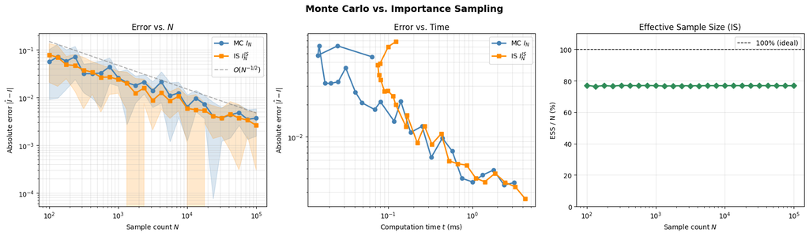

```python
fig, axes = plt.subplots(1, 3, figsize=(17, 5))
fig.suptitle('Monte Carlo vs. Importance Sampling', fontsize=14, fontweight='bold')

C = {'mc': 'steelblue', 'is': 'darkorange'}

# Panel 1: Error vs N
ax = axes[0]
ax.fill_between(N_values, mc_err_mean-mc_err_std, mc_err_mean+mc_err_std, alpha=0.2, color=C['mc'])
ax.fill_between(N_values, is_err_mean-is_err_std, is_err_mean+is_err_std, alpha=0.2, color=C['is'])
ax.loglog(N_values, mc_err_mean, 'o-', color=C['mc'], label=r'MC $I_N$',      lw=2)
ax.loglog(N_values, is_err_mean, 's-', color=C['is'], label=r'IS $I_N^{IS}$', lw=2)
ax.loglog(N_values, 1.5/np.sqrt(N_values), '--', color='grey', alpha=0.6, label=r'$O(N^{-1/2})$')
ax.set_xlabel('Sample count $N$'); ax.set_ylabel(r'Absolute error $|\hat{I}-I|$')
ax.set_title('Error vs. $N$'); ax.legend(); ax.grid(True, which='both', alpha=0.3)

# Panel 2: Error vs Time
ax = axes[1]
ax.loglog(mc_t, mc_err_mean, 'o-', color=C['mc'], label=r'MC $I_N$',      lw=2)
ax.loglog(is_t, is_err_mean, 's-', color=C['is'], label=r'IS $I_N^{IS}$', lw=2)
ax.set_xlabel('Computation time $t$ (ms)'); ax.set_ylabel(r'Absolute error $|\hat{I}-I|$')
ax.set_title('Error vs. Time'); ax.legend(); ax.grid(True, which='both', alpha=0.3)

# Panel 3: ESS
ax = axes[2]
ax.semilogx(N_values, ess_mean/N_values*100, 'D-', color='seagreen', lw=2)
ax.axhline(100, color='black', lw=1, ls='--', label='100% (ideal)')
ax.set_xlabel('Sample count $N$'); ax.set_ylabel('ESS / N (%)')
ax.set_title('Effective Sample Size (IS)'); ax.legend()
ax.grid(True, alpha=0.3); ax.set_ylim(0, 110)

plt.tight_layout()
# plt.savefig('mc_vs_is_error.png', dpi=150, bbox_inches='tight')
plt.show()
```

## 4. Estimate Trajectories with True Value

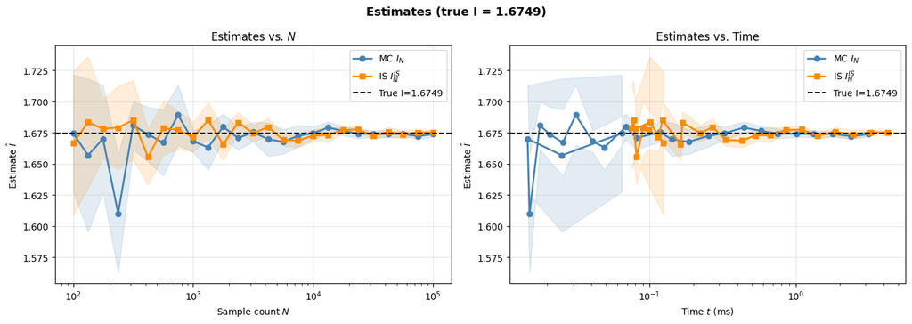

```python
mc_mean_est = mc_ests.mean(1)
is_mean_est = is_ests.mean(1)

fig, axes = plt.subplots(1, 2, figsize=(14, 5))
fig.suptitle(f'Estimates (true I = {TRUE_I})', fontsize=13, fontweight='bold')

for ax, xmc, xis, xlabel in [
    (axes[0], N_values, N_values, 'Sample count $N$'),
    (axes[1], mc_t,     is_t,     'Time $t$ (ms)'),
]:
    ax.semilogx(xmc, mc_mean_est, 'o-', color=C['mc'], label=r'MC $I_N$',      lw=2)
    ax.semilogx(xis, is_mean_est, 's-', color=C['is'], label=r'IS $I_N^{IS}$', lw=2)
    ax.axhline(TRUE_I, color='black', lw=1.5, ls='--', label=f'True I={TRUE_I}')
    ax.fill_between(xmc, mc_mean_est-mc_err_std, mc_mean_est+mc_err_std, alpha=0.15, color=C['mc'])
    ax.fill_between(xis, is_mean_est-is_err_std, is_mean_est+is_err_std, alpha=0.15, color=C['is'])
    ax.set_xlabel(xlabel); ax.set_ylabel(r'Estimate $\hat{I}$')
    ax.legend(); ax.grid(True, alpha=0.3)

axes[0].set_title('Estimates vs. $N$')
axes[1].set_title('Estimates vs. Time')
plt.tight_layout()
# plt.savefig('mc_vs_is_estimates.png', dpi=150, bbox_inches='tight')
plt.show()
```

## 5. Summary

[output not shown]

**Common mistake:** drawing u ~ g and applying weights |u|^{-alpha} does NOT produce a valid IS estimator for E_g[h]. Self-normalised IS requires samples from a *different* proposal q, with weights g/q correcting for the mismatch.